# Shrinkage with Lasso

Levi Lopes de Lima

2026-05-01

#### Explaining the lab

In this lab we illustrate the phenomenon of shrinkage in the setting of LASSO estimation. This celebrated procedure allows for the implementation of **variable selection** in a linear model when the number of features ($p$) is of the same order or even much larger than the number of observations ($n$): as explained below in the theoretical piece, these are regimes in which the standard methods of linear algebra and statistics fail to work!

Instead of working with real-workd data, we prefer here to explain the method by means of simulated data, as this turns the usage of this lab both reproducible and flexible.

We carry out this in two iterations:

- we first implement the simulation of a linear model with $p=20$ and $n=100$ in which only a few features are statistically significant (say, **four** of them). Even though we work here in the classical setting ($p<n$) and, moreover, we know beforehand which predictors are relevant, the aim is to check the effectiveness of LASSO as a variable selector. We emphasize that the simulation only applies to the design matrix ${\bf x}$ (chosen as a random matrix with standard normal entries) with the responses $y_i$ being computed from ${\bf x}$ and the prescribed (sparse) coefficient vector $\beta$ by means of the linear model formula below (with $e_i\sim\mathcal N(0,0.25)$).
- next we explore the fact that the underlying parameters of the simulation above have been wrapped in an appropriate R function (and hence may be modified at will) in order to simulate a data set with $p=150$ and $n=100$ to which we apply the LASSO. The resulting predictor is then evaluated using **conformal prediction**, which provides distribution-free measures of predictive accuracy via finite-sample valid prediction intervals.

All the math needed to understand the simulations in this lab may be found in (Lima 2025); see also (Hastie et al. 2015) for a full account of sparsity methods in Statistical Learning and (Angelopoulos et al. 2024) for conformal prediction.

#### A glimpse at the theory

Taken together, these perspectives provide the remarkable balance between **prediction** and **interpretability** which is so characteristic of OLS. But notice that this rather satisfactory state of affairs only works fine under the classical assumption $p\leq n$, which leaves open the question of how to proceed when the data fail to meet this requirement, which is the case commonly occurring in modern Data Science. Among the many shrinkage methods available to handle this issue, it turns out that the **LASSO estimator**,
$$\widehat\beta_L={\rm argmin}_\beta\,\frac{1}{2}\|{\bf y}-{\bf
x}\beta\|^2+\lambda\|\beta\|_1,$$
stands out as a most notable course of action.

In fact, even when $p<n$ but the number of predictors is large, the $\ell^1$ penalty acts as an automatic variable selector: among the many competing directions in the parameter space, only those with enough empirical support survive the mnimization, while the remaining coefficients are driven exactly to zero. In this regime, the LASSO is best viewed as a principled alternative to ad-hoc stepwise procedures (as the **backward selection** scheme used in the companion lab “Advertising”), with the additional advantage of being expressed as the solution of a convex optimization problem.

On the other hand, if $p>n$ the role of the method becomes even more structural. Here the OLS problem is no longer identifiable, and infinitely many coefficient vectors interpolate the data. The $\ell^1$ penalty resolves this indeterminacy by enforcing **sparsity**: the estimator searches for the simplest explanation compatible with the data, effectively reducing the dimensionality of the model while still allowing for stable estimation and prediction. In this sense, the same geometric mechanism that produces variable selection in the moderately high-dimensional case becomes a necessity in the genuinely high-dimensional one.

Thus, whether used as a selection tool in large but classical problems or as a full estimation principle in regimes where $p\gg n$, the LASSO is unified by a single idea: the geometry of the $\ell^1$ ball singles out sparse solutions in a transparent and mathematically controlled way. The purpose of this lab is precisely to illustrate the usage of the LASSO in both instances.

#### Starting the lab

As usual, we start by calling the pertinent R packages…

```r
library(tidyverse)
library(glmnet)
```

#### Iteration 1: Simulating a sparse linear model (with $p<n$) and applying the LASSO

To make our examples both reproducible and flexible, we’ll wrap the data simulation logic in a reusable R function, *simulate_lasso_data()*, as this allows us to easily change parameters like the number of observations (*n_obs*) or predictors (*n_pred*).

```r
simulate_lasso_data <- function(n_obs = 100, n_pred = 20, seed = 123) {
  set.seed(seed)

  # Generate the predictor matrix from a standard normal distribution
  x <- matrix(rnorm(n_obs * n_pred), nrow = n_obs, ncol = n_pred)

  # Create the true coefficients vector in a robust way, first zeroing all them and then assigning a few non-zero coefficients
  true_coefficients <- rep(0, n_pred)
  true_coefficients[1] <- 2.5
  true_coefficients[2] <- -1.8
  true_coefficients[3] <- 3.1
  true_coefficients[4] <- -4.3

  # Generate the response variable y: y = X * beta + noise
  y <- x %*% true_coefficients + rnorm(n_obs, sd = 0.5)

  # Return all relevant objects in a named list
  return(list(x = x, y = y, true_coefficients = true_coefficients))
}

# Next we call the previously defined function to generate our data: we use the default values (100 observations, 20 predictors, seed = 123), but these inputs can be changed at will
sim_data <- simulate_lasso_data()

# Extract the components from the list for use in later chunks
x <- sim_data$x
y <- sim_data$y
true_coefficients <- sim_data$true_coefficients

cat(paste("Simulated data created using a function with",
          nrow(x), "observations and", ncol(x), "predictors.\n"))
```

```
## Simulated data created using a function with 100 observations and 20 predictors.
```

With the simulated data at hand, from this point on we pretend that they have been obtained elsewhere, so we fit an OLS to them in the usual manner (which we can do because $p=20<n=100$).

```r
ols_model <- lm(y ~ x)
summary(ols_model)
```

```
##
## Call:
## lm(formula = y ~ x)
##
## Residuals:
##      Min       1Q   Median       3Q      Max
## -1.05755 -0.25490 -0.00788  0.31716  0.90654
##
## Coefficients:
##               Estimate Std. Error t value Pr(>|t|)
## (Intercept) -0.0663802  0.0501300  -1.324    0.189
## x1           2.4634050  0.0554553  44.421   <2e-16 ***
## x2          -1.8356466  0.0533434 -34.412   <2e-16 ***
## x3           3.1881754  0.0529902  60.165   <2e-16 ***
## x4          -4.3031726  0.0513763 -83.758   <2e-16 ***
## x5           0.0077358  0.0511939   0.151    0.880
## x6          -0.0001458  0.0555115  -0.003    0.998
## x7           0.0098167  0.0480692   0.204    0.839
## x8          -0.0572700  0.0507185  -1.129    0.262
## x9          -0.0057853  0.0464978  -0.124    0.901
## x10          0.0097082  0.0512935   0.189    0.850
## x11          0.0791244  0.0542503   1.459    0.149
## x12          0.0065411  0.0516930   0.127    0.900
## x13         -0.0664675  0.0556742  -1.194    0.236
## x14          0.0146912  0.0517827   0.284    0.777
## x15          0.0234506  0.0509395   0.460    0.647
## x16         -0.0148443  0.0600672  -0.247    0.805
## x17         -0.0226735  0.0507925  -0.446    0.657
## x18         -0.0240579  0.0496791  -0.484    0.630
## x19          0.0176825  0.0481023   0.368    0.714
## x20         -0.0734108  0.0462398  -1.588    0.116
## ---
## Signif. codes:  0 '***' 0.001 '**' 0.01 '*' 0.05 '.' 0.1 ' ' 1
##
## Residual standard error: 0.4588 on 79 degrees of freedom
## Multiple R-squared:  0.9956, Adjusted R-squared:  0.9945
## F-statistic: 900.4 on 20 and 79 DF,  p-value: < 2.2e-16
```

As expected, besides confirming that the only statistically significant predictors are $x_1$, $x_2$, $x_{3}$ and $x_{4}$, the associated summary provides an almost perfect goodness-of-fit for the model: $R^2=0.995$ and a very small $p$-value for the corresponding $F$-statistics. Another way of checking this is to fit a partial OLS model with only the relevant predictors …

```r
ols_model_adj <- lm(y ~ x[,1] + x[,2] + x[,3] + x[,4])
summary(ols_model_adj)
```

```
##
## Call:
## lm(formula = y ~ x[, 1] + x[, 2] + x[, 3] + x[, 4])
##
## Residuals:
##      Min       1Q   Median       3Q      Max
## -1.08706 -0.30550 -0.02126  0.30057  0.96078
##
## Coefficients:
##             Estimate Std. Error t value Pr(>|t|)
## (Intercept) -0.06554    0.04547  -1.441    0.153
## x[, 1]       2.45423    0.04956  49.521   <2e-16 ***
## x[, 2]      -1.82767    0.04640 -39.388   <2e-16 ***
## x[, 3]       3.16077    0.04760  66.405   <2e-16 ***
## x[, 4]      -4.30450    0.04323 -99.579   <2e-16 ***
## ---
## Signif. codes:  0 '***' 0.001 '**' 0.01 '*' 0.05 '.' 0.1 ' ' 1
##
## Residual standard error: 0.4454 on 95 degrees of freedom
## Multiple R-squared:  0.9951, Adjusted R-squared:  0.9948
## F-statistic:  4774 on 4 and 95 DF,  p-value: < 2.2e-16
```

… and run an ANOVA to compare the models:

```r
anova(ols_model_adj,ols_model)
```

```
## Analysis of Variance Table
##
## Model 1: y ~ x[, 1] + x[, 2] + x[, 3] + x[, 4]
## Model 2: y ~ x
##   Res.Df    RSS Df Sum of Sq      F Pr(>F)
## 1     95 18.842
## 2     79 16.627 16    2.2156 0.6579 0.8256
```

…so the large $p$-value ($\approx 0.825$) indicates that the models are statistically indistinguishable.

Similarly to what has been done in a companion lab (“Advertising”), the natural way to proceed from here would be to apply **backward selection** to the full model by removing an irrelevant predictor at a time, a daunting task indeed given the large value of $p$ (one would need **16** steps to carry this over!). Instead, with our predictor matrix ${\bf x}$ and response vector ${\bf y}$ at hand, we will directly check whether LASSO can recover the true coefficients we prescribed, correctly identifying that most predictors are irrelevant indeed.

We use the `glmnet()` function to fit the model: setting *alpha = 1* specifies that we want to perform LASSO regression.

```r
lasso_model <- glmnet(x, y, alpha = 1)
print(lasso_model)
```

```
##
## Call:  glmnet(x = x, y = y, alpha = 1)
##
##    Df  %Dev Lambda
## 1   0  0.00 4.7580
## 2   1 10.10 4.3360
## 3   1 18.48 3.9500
## 4   1 25.44 3.6000
## 5   1 31.22 3.2800
## 6   1 36.02 2.9880
## 7   2 40.43 2.7230
## 8   2 46.76 2.4810
## 9   2 52.01 2.2610
## 10  3 56.80 2.0600
## 11  3 62.68 1.8770
```

[output cut: 55 more lines]

The output shows that `glmnet()` doesn’t just fit one model, but an entire path of models for 66 different values of $\lambda$ (the regularization penalty). Notice how `Df` (degrees of freedom, or the number of non-zero coefficients) starts high when $\lambda$ is small and decreases to zero as $\lambda$ gets larger and the penalty becomes stronger. It turns out that a **path plot** is the best way to visualize how LASSO shrinks coefficients towards (and eventually to) zero as the penalty $\lambda$ increases.

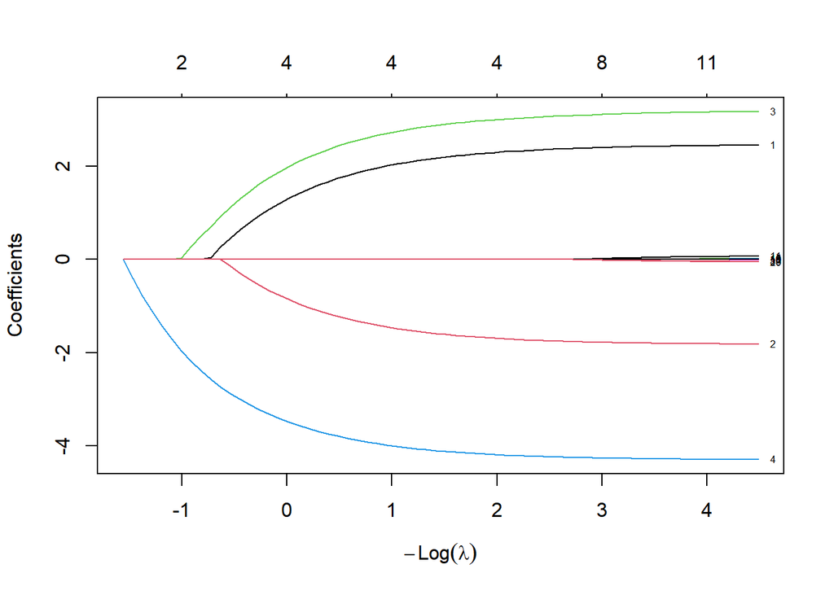

```r
plot(lasso_model, xvar = "lambda", label = TRUE)
```

Each line represents one of the 20 predictor variables. The Y-axis shows the coefficient’s value, and the X-axis shows the minus log of the penalty term $\lambda$. As we move from left to right (decreasing penalty), more variables enter the model with non-zero coefficients. As we move from right to left (increasing penalty), coefficients are “shrunk” to zero. The numbers at the top indicate how many variables are in the model at that point. We can clearly see that only a few variables have large, persistent coefficients.

Fitting a path of models is great, but we need to choose the single best value for $\lambda$. For this we use $k$-fold **cross-validation** with $k=10$, which helps us finding the $\lambda$ that minimizes prediction error on unseen data; see (Chetverikov et al. 2021) for a formal justification of this crucial step.

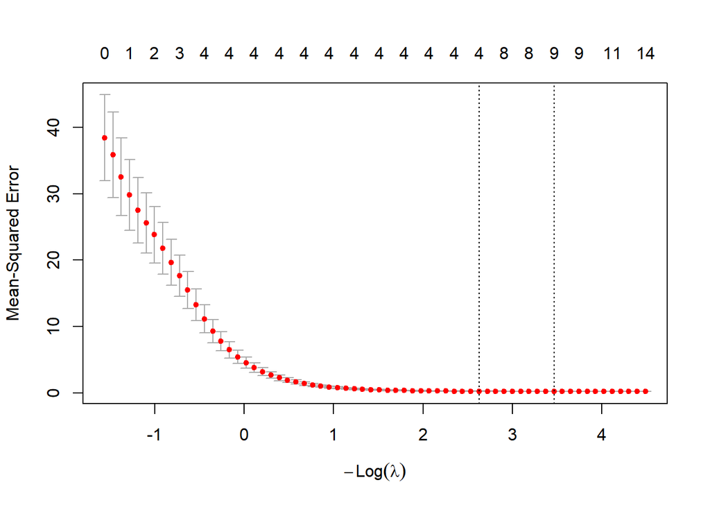

```r
cv_lasso <- cv.glmnet(x, y, alpha = 1, nfolds = 10)
plot(cv_lasso)
```

##### A theoretical digression

It is worthwhile to explain how this plot is obtained in general. We start by randomly splitting the data set $\{({\bf x}_i),{\bf y}_i\}_{i=1}^n$ into approximately $k$ equal-sized groups, called **folds**. Now, for each value of $\lambda$ we proceed as follows:

- Hold out fold 1 as a test set and fit the LASSO using the remaining $k-1$ folds.
- Predict the responses of the held-out fold using the fitted model.
- Compute ${\rm mse}_1(\lambda)$, the mean squared error, on that fold.
- Repeat the steps above for folds 2,3,…, k.

Since every fold plays the role of “unseen data” exactly once, we should average the $k$ separated prediction errors,
$$CV(\lambda)=\frac{1}{k}\sum_{l=1}^k{\rm mse}_l(\lambda),$$
so the plot shows this cross-validated error versus $-\log(\lambda)$, with the two vertical dashed lines indicating two common choices for the optimal $\lambda$:

- `lambda.min`: The $\lambda$ that gives the absolute lowest cross-validated error, corresponding to the dashed line on the right.
- `lambda.1se`: The $\lambda$ from the most parsimonious (simplest) model whose error is within one standard error of the minimum, corresponding to the dashed line on the left. This is often preferred as it yields a simpler model with statistically similar performance.

With the theoretical explanation on how $k$-fold cross-validation produces the previous plot out of the way, we now extract the optimal $\lambda$ values identified by this process.

```r
# This extracts the lambda value corresponding to the minimum cross-validated error.
lambda_min <- cv_lasso$lambda.min
# This extracts the lambda value corresponding to the "one-standard error" rule.
lambda_1se <- cv_lasso$lambda.1se

cat("Optimal lambda (lambda.min):", lambda_min, "\n")
```

```
## Optimal lambda (lambda.min): 0.03130698
```

```r
cat("Parsimonious lambda (lambda.1se):", lambda_1se, "\n")
```

```
## Parsimonious lambda (lambda.1se): 0.07232318
```

…and use them to view the final model coefficients (note that $\lambda=e^{-\alpha}$, where $\alpha\approx 3.464$ and $\alpha\approx 2.631$ correspond to the values where the dashed vertical lines cut the horizontal axis).

We start with the model using `lambda_min`:

```r
coef_min <- coef(lasso_model, s = lambda_min)
#cat("\nCoefficients using lambda.min:\n")
print(coef_min)
```

```
## 21 x 1 sparse Matrix of class "dgCMatrix"
##              s=0.03130698
## (Intercept) -0.0545262335
## V1           2.4216360737
## V2          -1.7979482131
## V3           3.1365210810
## V4          -4.2771382775
## V5           .
## V6           .
## V7           .
## V8          -0.0329496518
## V9           .
## V10          .
## V11          0.0422889671
## V12          .
## V13         -0.0270354333
## V14          0.0004170055
## V15          .
## V16          .
## V17          .
## V18          .
## V19          .
## V20         -0.0354160668
```

In order to focus on relevant information in the previous summary, we use a function to extract the **non-zero** coefficients of the model…

```r
print_nonzero_coefs <- function(coef_mat) {
  # coef_mat: output of coef(glmnet_object, s = ...)

  coef_vec <- as.numeric(coef_mat)
  names(coef_vec) <- rownames(coef_mat)

  nz_coef <- coef_vec[coef_vec != 0]

  print(nz_coef)
}
```

…which may be called as follows:

```r
coef_min_nz <- coef(lasso_model, s = lambda_min)
print_nonzero_coefs(coef_min_nz)
```

```
##   (Intercept)            V1            V2            V3            V4
## -0.0545262335  2.4216360737 -1.7979482131  3.1365210810 -4.2771382775
##            V8           V11           V13           V14           V20
## -0.0329496518  0.0422889671 -0.0270354333  0.0004170055 -0.0354160668
```

We now turn to `lambda_1se`, this time using the new function `print_nonzero_coefs()`:

```r
coef_1se_nz <- coef(lasso_model, s = lambda_1se)
print_nonzero_coefs(coef_1se_nz)
```

```
## (Intercept)          V1          V2          V3          V4
## -0.03769159  2.36975550 -1.75669995  3.07450639 -4.24423533
```

This model is more parsimonious, with only 4 non-zero coefficients. When compared to the previous one, it also correctly identifies the four true predictors (up to a small error) and eliminates more of the noise variables. This demonstrates LASSO’s power in feature selection. Also, this provides further justification for using the model `ols_model_adj` above which, as we have seen, fits remarkably well to the data with $R^2=0.9951$ (as expected, since we created the pre-selected data ourselves from a linear model).

#### Iteration 2: Using LASSO to handle a sparse linear model (with $p>n$)

We now handle examples in the truly high-dimensional regime ($p>n$). The idea is to use the already available function `simulate_lasso_data()` to simulate the corresponding data set:

```r
sim_data_new <- simulate_lasso_data(100, 150, 456)

x <- sim_data_new$x
y <- sim_data_new$y
true_coefficients <- sim_data_new$true_coefficients

cat(paste("Simulated data with",
          nrow(x), "observations and", ncol(x), "predictors.\n"))
```

```
## Simulated data with 100 observations and 150 predictors.
```

```r
str(sim_data_new)
```

```
## List of 3
##  $ x                : num [1:100, 1:150] -1.344 0.622 0.801 -1.389 -0.714 ...
##  $ y                : num [1:100, 1] 2.9 1.68 4.82 -13.32 2.72 ...
##  $ true_coefficients: num [1:150] 2.5 -1.8 3.1 -4.3 0 0 0 0 0 0 ...
```

Since $p=150>n=100$, it is out of question to fit an OLS to the simulated data, so we immediately pass to the LASSO.

```r
lasso_model_new <- glmnet(x, y, alpha = 1)
```

We refrain from printing the quite long model summary and pass directly to the corresponding path plot…

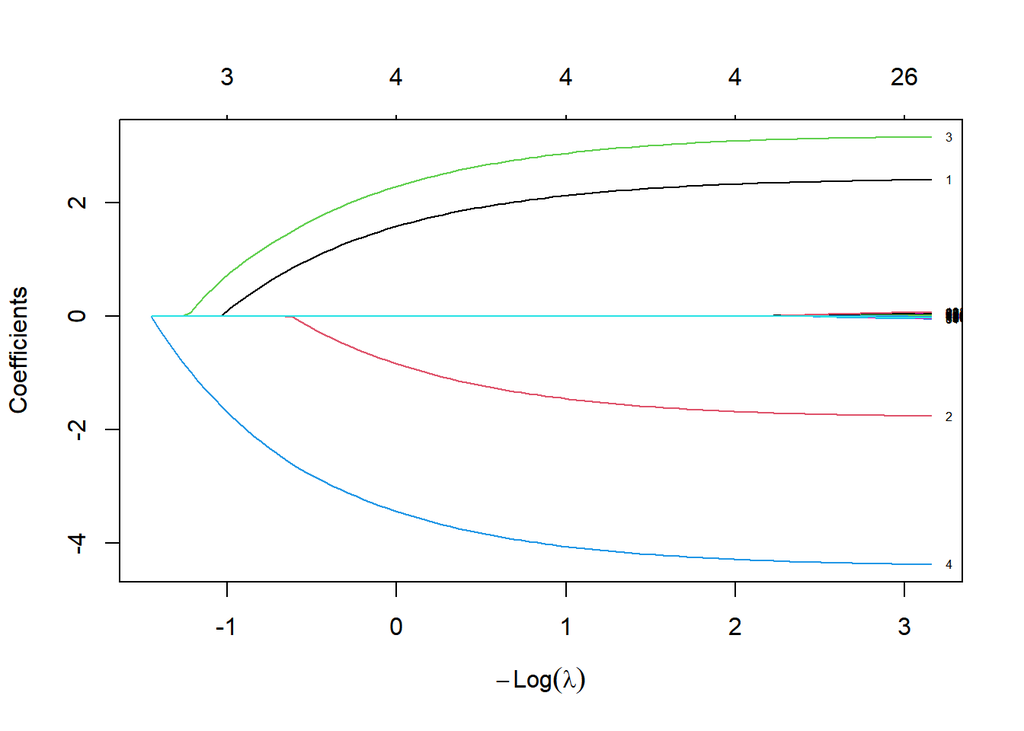

```r
plot(lasso_model_new, xvar = "lambda", label = TRUE)
```

…followed by the associated $k$-fold cross-validation (with $k=20$):

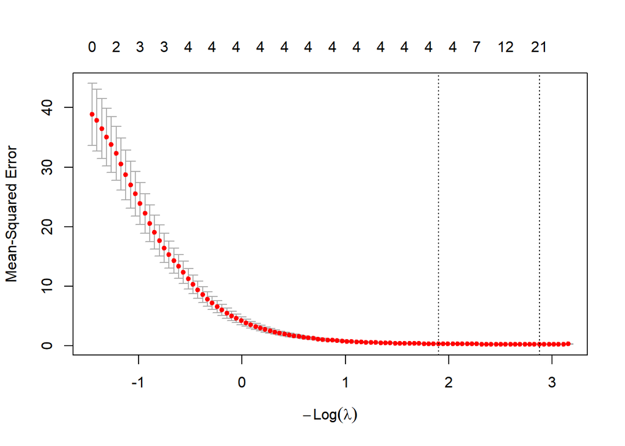

```r
cv_lasso_new <- cv.glmnet(x, y, alpha = 1, nfolds = 20)
plot(cv_lasso_new)
```

We now extract the relevant pair of $\lambda$ values:

```r
lambda_min_new <- cv_lasso_new$lambda.min
lambda_1se_new <- cv_lasso_new$lambda.1se
cat("Optimal lambda (lambda.min):", lambda_min_new, "\n")
```

```
## Optimal lambda (lambda.min): 0.05634434
```

```r
cat("Parsimonious lambda (lambda.1se):", lambda_1se_new, "\n")
```

```
## Parsimonious lambda (lambda.1se): 0.1496555
```

We now extract the non-zero coefficients of the model corresponding to `lambda_min_new`:

```r
coef_min__new_nz <- coef(lasso_model_new, s = lambda_min_new)
print_nonzero_coefs(coef_min__new_nz)
```

```
##  (Intercept)           V1           V2           V3           V4          V22
##  0.137020370  2.397968032 -1.747207844  3.152121038 -4.360791500  0.047329314
##          V23          V41          V45          V51          V62          V67
##  0.053731636  0.009984360  0.006428679 -0.032028984  0.017089005  0.027324059
##          V70          V73          V79          V83          V91         V129
##  0.014950831  0.006539472  0.017772643 -0.021485274  0.030528071 -0.016979024
##         V135         V138         V145         V150
## -0.001640638  0.061486174  0.017607251 -0.018356651
```

This models selects the significant coefficients and shrinks most of the remaining coefficients to 0, but 17 (very small) coefficients remain, so we pass to the model corresponding to `lambda_1se_new`:

```r
coef_1se__new_nz <- coef(lasso_model_new, s = lambda_1se_new)
print_nonzero_coefs(coef_1se__new_nz)
```

```
## (Intercept)          V1          V2          V3          V4
##   0.1449035   2.3185334  -1.6630094   3.0768139  -4.2689029
```

… so that now only the four significant coefficients have survived. Note that they match their true values up to a small error, which confirms the efficiency of the LASSO as a tool which implements variable selection (via shrinkage) and restores interpretability.

#### Checking LASSO accuracy with (Split) Conformal Prediction

With the option `lambda_1se_new` above, LASSO has provided us with the fitted model
$$\widehat y=\widehat f(\widehat x):=0.14+2.31\widehat x_1-1.66\widehat
x_2+3.076\widehat x_3-
4.26\widehat x_4+
0.00 \widehat x_5+\cdots,$$
by means of which we can make **prediction** in the usual way: we enter with a new, independent covariate vector $\widehat x=(\widehat x_1,\widehat x_4,\widehat x_,\widehat x_4,\widehat x_5,\cdots)$, drawn from the same distribution used to generated the training data, and use the above formula to get the predicted answer $\widehat y$. We may evaluate the accuracy of this procedure by means of the high probabiblity bounds in (Lima 2025), but we prefer instead to proceed in a different manner and use **Conformal Prediction** to this effect.

The first step is to draw, again from the same distribution, a fresh **calibraton data set** $(x_i^c,y_i^c)\in\mathbb R^{p}\times \mathbb R$, $i=1,\dots,n$,…

```r
## Fresh calibration sample (with n=n_obs and p=n_pred)
calib_data <- simulate_lasso_data(n_obs = 100, n_pred = 150, seed = 222)
```

…which will be used to compute the **conformity scores** by means of the corresponding absolute residuals
$$S_i=|y^c_i-\widehat f(x^c_i)|.$$

```r
## Calibration scores
calib_pred <- predict(
  lasso_model_new,
  newx = calib_data$x,
  s = lambda_1se_new
)
scores <- abs(calib_data$y - as.vector(calib_pred))
```

Clearly, this measures the overall discrepancy between the response $y^c$ and the prediction $\widehat f(x^c)$ across the complementary calibration data set, hence the **conformity** terminology. Note that this inherits the structure of the underlying learning algorithm $\widehat f$.

```r
alpha_cp <- 0.1
m <- length(scores)
k <- ceiling((1 - alpha_cp) * (m + 1))
k <- min(k, m)
q_hat <- sort(scores)[k]
```

The key point now is that, as explained in (Angelopoulos and Bates 2023), each new test data point $(x_{\rm new},y_{\rm new})$, again independently drawn from the same population, satisfies the **conformal prediction bound**
$$P(y_{\rm new}\in[\widehat f(x_{\rm new})-\widehat q,\widehat f(x_{\rm
new})+\widehat q])\geq 1-\alpha.$$
In summary, the conformity scores are the absolute residuals of the LASSO model on the calibration sample, which are then employed to estimate the typical prediction error used to construct the prediction intervals. Note that the lengths of these intervals remain constant across the calibration:

```r
length_pred_int <- 2*q_hat
length_pred_int
```

```
## [1] 2.270238
```

We now turn to the empirical confirmation of these prediction intervals. For this we draw, again from the same population, a fresh **test data set** $(x_j^t,y_j^t)\in\mathbb R^p\times\mathbb R$, $j=1,\dots, n_t$, which is supposed to contain $(x_{\rm new},y_{\rm new})$ above (we take $n_t=1000$ for concreteness). This allows us to define the **empirical coverage** as the random variable counting the frequency according to which $y_j^t$ falls within the corresponding prediction interval (centered at $\widehat f(x_j^t)$):
$$\widehat{\mathrm{EC}}
=
\frac{1}{n_{{t}}}
\sum_{j=1}^{n_{{t}}}
\mathbf{1}_{\left\{
\widehat f(X_j^{{t}}) - \widehat q
\;\le\;
Y_j^{{t}}
\;\le\;
\widehat f(X_j^{{t}}) + \widehat q
\right\}}.$$

```r
## --- Test prediction intervals ---
test_data  <- simulate_lasso_data(n_obs = 1000, n_pred = 150, seed = 333)

test_pred <- predict(
  lasso_model_new,
  newx = test_data$x,
  s = lambda_1se_new
)
test_pred <- as.vector(test_pred)

lower <- test_pred - q_hat
upper <- test_pred + q_hat

coverage <- mean(test_data$y >= lower & test_data$y <= upper)
coverage
```

```
## [1] 0.944
```

The observed coverage $.944$ exceeds the nominal level $1-\alpha=0.9$ not only due to the finite-sample conservativeness of conformal prediction, but also because the LASSO estimator selected via the 1-SE rule tends to underfit, leading to inflated residuals and consequently wider prediction intervals.

We may also plot the variation of this empirical coverage against the number of observations in the test set…

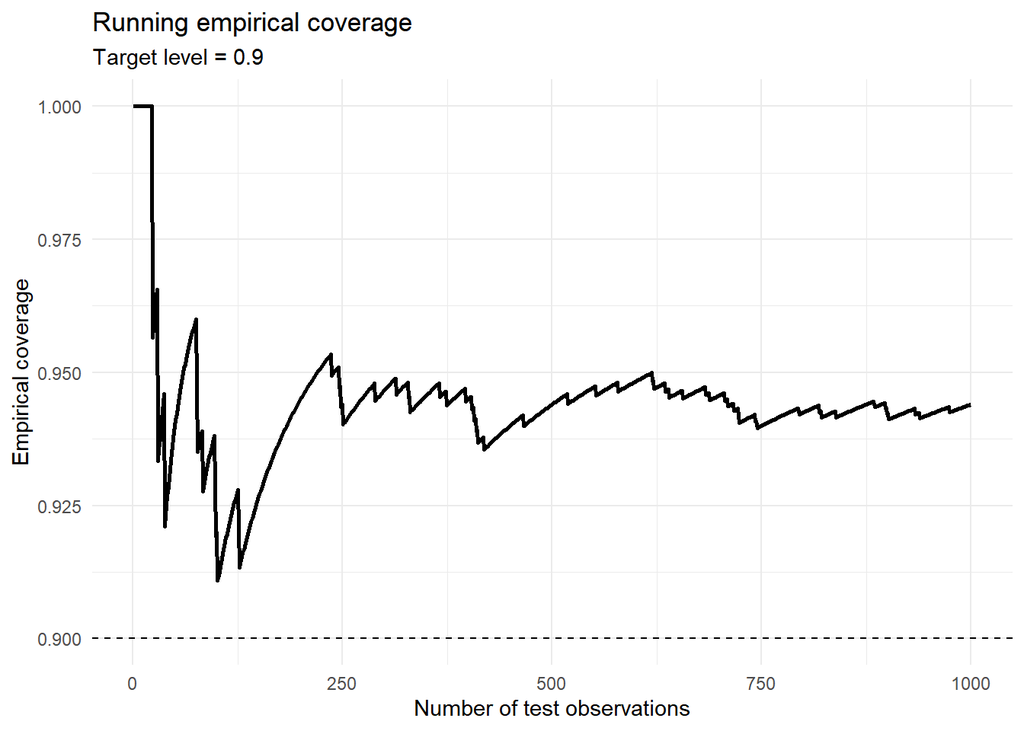

```r
library(ggplot2)
covered <- (test_data$y >= lower) & (test_data$y <= upper)
n_test <- length(covered)
cum_coverage <- cumsum(covered) / (1:n_test)
df_cov <- data.frame(
  k = 1:n_test,
  coverage = cum_coverage
)
ggplot(df_cov, aes(x = k, y = coverage)) +
  geom_line(linewidth = 1) +
  geom_hline(yintercept = 1 - alpha_cp, linetype = "dashed") +
  labs(
    title = "Running empirical coverage",
    subtitle = paste0("Target level = ", 1 - alpha_cp),
    x = "Number of test observations",
    y = "Empirical coverage"
  ) +
  theme_minimal()
```

We may also visualize the distribution of the prediction intervals (we use only the first 50 test points for readability):

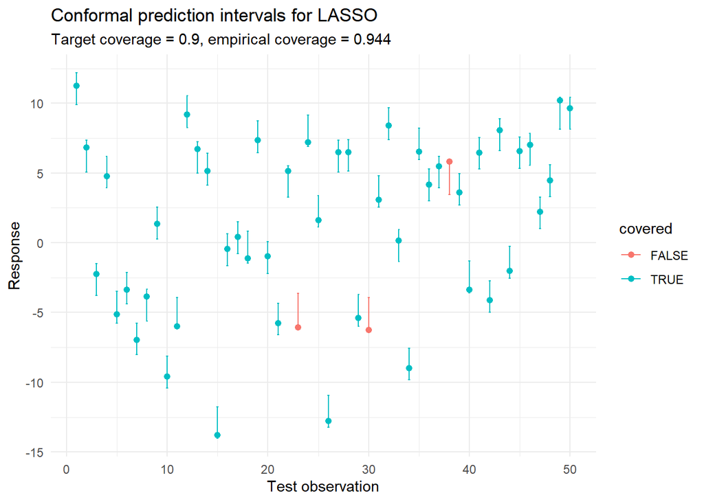

```r
plot_data <- data.frame(
  index = 1:length(test_data$y),
  y_true = test_data$y,
  lower = lower,
  upper = upper,
  covered = test_data$y >= lower & test_data$y <= upper
)

plot_data_small <- plot_data[1:50, ]

ggplot(plot_data_small, aes(x = index, y = y_true)) +
  geom_errorbar(aes(ymin = lower, ymax = upper, color = covered), width = 0.2) +
  geom_point(aes(color = covered), size = 1.8) +
  labs(
    title = "Conformal prediction intervals for LASSO",
    subtitle = paste0(
      "Target coverage = ", 1 - alpha_cp,
      ", empirical coverage = ", round(coverage, 3)
    ),
    x = "Test observation",
    y = "Response"
  ) +
  theme_minimal()
```

Finally, we may plot a histogram for the empirical distribution of the calibration errors used to build the conformal intervals:

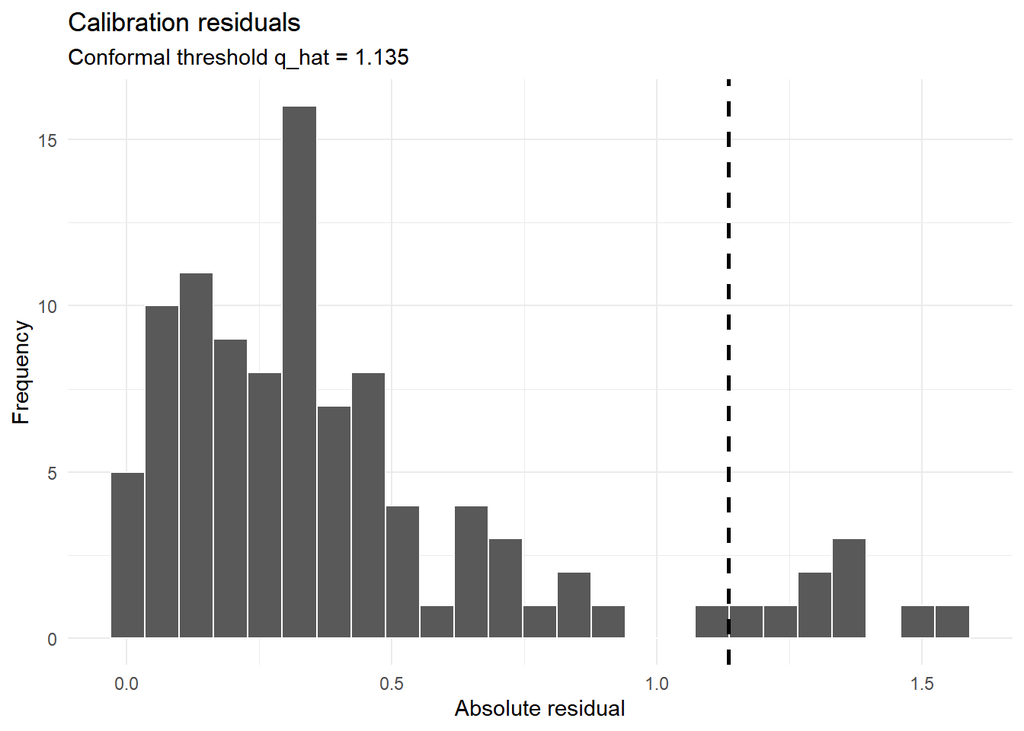

```r
calib_scores <- data.frame(scores = scores)

ggplot(calib_scores, aes(x = scores)) +
  geom_histogram(bins = 25, color = "white") +
  geom_vline(xintercept = q_hat, linetype = "dashed", linewidth = 1) +
  labs(
    title = "Calibration residuals",
    subtitle = paste0("Conformal threshold q_hat = ", round(q_hat, 3)),
    x = "Absolute residual",
    y = "Frequency"
  ) +
  theme_minimal()
```

Since bars to the left of the dashed line correspond to calibration errors covered by the chosen threshold $\widehat q$ and bars to the right are associated to large calibration errors beyond this threshold, this plot explains visually where the interval radius comes from: the conformal prediction is using the upper tail of the calibration residuals to choose a safe prediction-error margin.

We end up this lab with a few general comments regarding conformal prediction:

– In contrast to the **conditional** prediction bounds for the LASSO discussed in (Lima 2025), which rely on the **fixed design assumption**, where the covariates are treated as deterministic and all randomness is attributed to the noise, thereby exploiting both the linear structure and the Gaussianity of the model, the conformal prediction intervals constructed above are **marginal** in nature, in the sense that their coverage guarantee holds on average over the joint distribution of the data. Despite this apparent drawback, the method has the advantage of remaining valid when the covariates themselves are random.

– Another key point is that the validity of the prediction intervals constructed above is distribution-free, while their size reflects the accuracy of the underlying predictor $\widehat f$. This decoupling makes conformal prediction not only compatible with the LASSO, where classical inference typically breaks down in the high-dimensional regime $p\gg n$, but also well suited to the broader demands of Statistical Learning.

– Although in the application to the LASSO above, and more generally in Statistical Learning, one typically assumes that the sample is i.i.d., the validity properties of conformal prediction continue to hold under the weaker assumption of **exchangeability**, that is, when the joint distribution of the sample is invariant under arbitrary permutations of its entries, with these guarantees remaining completely model-agnostic and applying to any predictor $\widehat f$, the latter influencing only the efficiency (i.e., the size) of the resulting prediction intervals. Additionally, if the conformity scores are almost surely distinct (i.e., there are no ties) then the conformal prediction interval also satisfies the upper bound
$$P(y_{\rm new}\in[\widehat f(x_{\rm new})-\widehat q,\widehat f(x_{\rm
new})+\widehat q])
\;\le\;
1 - \alpha + \frac{1}{n+1},$$
where $n$ denotes the size of the calibration sample. This highlights the robustness of conformal prediction, which achieves valid uncertainty quantification independently of the complexity or correctness of the underlying model.

For an account of conformal prediction in textbook form, we refer to (Angelopoulos et al. 2024).

#### References

Angelopoulos, Anastasios N, Rina Foygel Barber, and Stephen Bates. 2024. “Theoretical Foundations of Conformal Prediction.” *arXiv:2411.11824*.

Angelopoulos, Anastasios N, and Stephen Bates. 2023. “Conformal Prediction: A Gentle Introduction.” *Foundations and Trends in Machine Learning* 16 (4): 494–591.

Chetverikov, Denis, Zhipeng Liao, and Victor Chernozhukov. 2021. “On Cross-Validated Lasso in High Dimensions.” *The Annals of Statistics* 49 (3): 1300–1317.

Hastie, Trevor, Robert Tibshirani, and Martin Wainwright. 2015. *Statistical Learning with Sparsity: The Lasso and Generalizations*. CRC press.

Lima, Levi Lopes de. 2025. *Topics in Probability, Parametric Estimation and Stochastic Calculus*. https://arxiv.org/abs/2510.20163.

[^1]: For simplicity here we set the intercept $\beta_0=0$, so that $\mathfrak x$ in (Lima (2025)) gets replaced by ${\bf x}$.